# Kepler analysis

Author

Aliaksandr Hubin

Published

2025-08-19

## 0.1 Load FBMS library

```r
# most recent per 02.07.2025 version from git
# devtools::install_github("jonlachmann/GMJMCMC@data-inputs", force=T, build_vignettes=F)
library(FBMS)
```

# 1 Load the data

```r
# Load data
data.train <- readRDS("train.RDS")
data.test <- readRDS("test.RDS")

# Function to compute summary stats
get_summary_stats <- function(df) {
  numeric_vars <- sapply(df, is.numeric)
  df_num <- df[, numeric_vars]
  t(apply(df_num, 2, function(x) {
    c(Min = min(x, na.rm = TRUE),
      Q1 = quantile(x, 0.25, na.rm = TRUE),
      Median = median(x, na.rm = TRUE),
      Q3 = quantile(x, 0.75, na.rm = TRUE),
      Max = max(x, na.rm = TRUE))
  }))
}

# Compute summaries
train_summary <- get_summary_stats(data.train)
test_summary  <- get_summary_stats(data.test)
```

Display ummary table for training set

```r
knitr::kable(round(train_summary, 4), caption = "Summary statistics for the training set (Min, Q1, Median, Q3, Max)")
```

Summary statistics for the training set (Min, Q1, Median, Q3, Max)

|  | Min | Q1.25% | Median | Q3.75% | Max |
| --- | --- | --- | --- | --- | --- |
| semimajoraxis | 0.0092 | 0.0441 | 0.0611 | 0.1426 | 6.7960e+01 |
| mass | 0.0000 | 0.0256 | 0.2910 | 1.0555 | 7.9000e+01 |
| radius | 0.0164 | 0.2315 | 0.9100 | 1.1965 | 2.0850e+00 |
| period | 0.4900 | 3.4560 | 5.4258 | 19.7148 | 1.6651e+05 |
| eccentricity | -0.1293 | 0.0000 | 0.0000 | 0.1020 | 9.3370e-01 |
| hoststar_mass | 0.0890 | 0.8400 | 1.0000 | 1.1800 | 2.8200e+00 |
| hoststar_radius | 0.1210 | 0.8200 | 1.0200 | 1.4340 | 8.6400e+01 |
| hoststar_metallicity | -0.9200 | -0.0600 | 0.0700 | 0.1800 | 5.2000e-01 |
| hoststar_temperature | 2516.0000 | 5070.5000 | 5638.0000 | 5981.0000 | 8.5000e+03 |
| binaryflag | 0.0000 | 0.0000 | 0.0000 | 0.0000 | 2.0000e+00 |

and for test set

```r
knitr::kable(round(test_summary, 4), caption = "Summary statistics for the test set (Min, Q1, Median, Q3, Max)")
```

Summary statistics for the test set (Min, Q1, Median, Q3, Max)

|  | Min | Q1.25% | Median | Q3.75% | Max |
| --- | --- | --- | --- | --- | --- |
| semimajoraxis | 0.0106 | 0.0416 | 0.0574 | 0.1164 | 22.1877 |
| mass | 0.0003 | 0.0251 | 0.2440 | 1.0577 | 13.0000 |
| radius | 0.0560 | 0.2180 | 0.8245 | 1.1700 | 2.0300 |
| period | 0.4466 | 3.1896 | 4.8755 | 15.4463 | 36336.7068 |
| eccentricity | 0.0000 | 0.0000 | 0.0077 | 0.1158 | 0.9210 |
| hoststar_mass | 0.0890 | 0.8400 | 0.9900 | 1.1607 | 2.0700 |
| hoststar_radius | 0.1210 | 0.8200 | 1.0200 | 1.3420 | 6.3000 |
| hoststar_metallicity | -0.5430 | -0.0700 | 0.0500 | 0.1900 | 7.7900 |
| hoststar_temperature | 2516.0000 | 5080.0000 | 5669.5000 | 6036.2500 | 9360.0000 |
| binaryflag | 0.0000 | 0.0000 | 0.0000 | 0.0000 | 2.0000 |

# 2 Bayesian generalized nonlinear models

We employ Bayesian Generalized Nonlinear Models (BGNLM) using Jeffreys priors under the assumption of unit variance. Inference is performed using the GMJMCMC algorithm, configured with 20 populations and 32 parallel chains to ensure robust exploration of the model space.

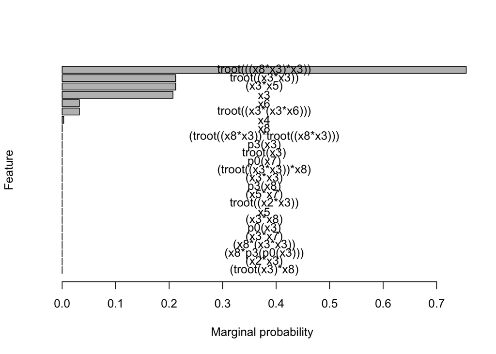

```r
transforms <- c("sin_deg","exp_dbl","p0","troot","p3")
probs <- gen.probs.gmjmcmc(transforms)
params <- gen.params.gmjmcmc(ncol(data.train)-1)
set.seed(1)
bgnlm <- FBMS::fbms(semimajoraxis ~ ., data = data.train,method = "gmjmcmc.parallel",beta_prior = list(type = "Jeffreys-BIC", var = 1),transforms = transforms,runs = 32,cores = 8,P = 20, probs = probs, params = params)
plot(bgnlm)
```

```r
summary(bgnlm)
```

| feats.strings | marg.probs |
| --- | --- |
| troot(((hoststar_temperature*period)*period)) | 0.7552726 |
| troot((period*period)) | 0.2123647 |
| (period*hoststar_mass) | 0.2123430 |
| period | 0.2071275 |
| hoststar_radius | 0.0322763 |
| troot((period*(period*hoststar_radius))) | 0.0322758 |
| eccentricity | 0.0028703 |
| hoststar_temperature | 0.0001304 |

check convergence

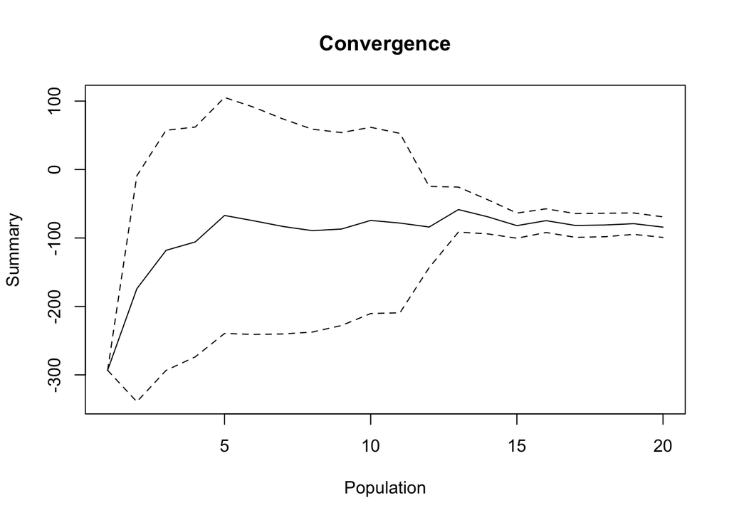

```r
p1 <- diagn_plot(bgnlm,window = 10,FUN = median)
```

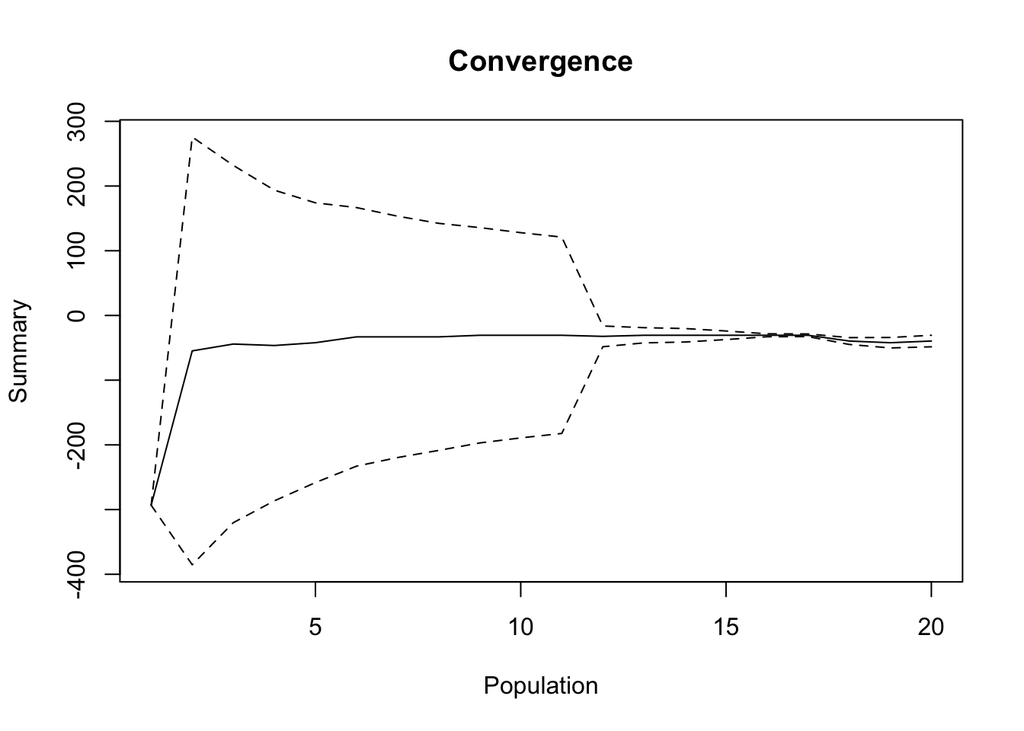

```r
p2 <- diagn_plot(bgnlm,window = 10,FUN = max)
```

We observe signs of possible convergence in the later generations of the GMJMCMC algorithm. However, to confirm this, we will increase computational resources and rerun the inference. It is important to note that convergence diagnostics can be misleading—they may indicate apparent convergence when the algorithm has simply become trapped in a strong local mode without adequately exploring other regions of the model space.

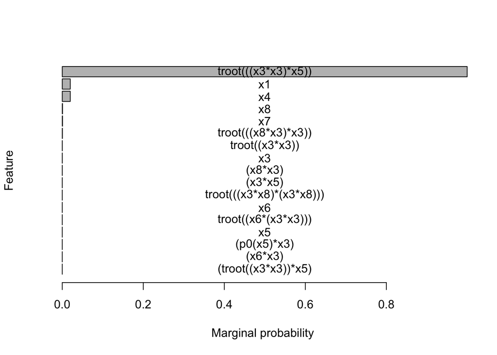

```r
set.seed(2)
bgnlm <- FBMS::fbms(semimajoraxis ~ ., data = data.train,method = "gmjmcmc.parallel",beta_prior = list(type = "Jeffreys-BIC", var = 1),transforms = transforms,runs = 64,cores = 8,P = 50,probs = probs, params = params)
plot(bgnlm)
```

```r
summary(bgnlm,labels = names(data.train)[-1])
```

| feats.strings | marg.probs |
| --- | --- |
| troot(((period*period)*hoststar_mass)) | 0.9995079 |
| mass | 0.0197110 |
| eccentricity | 0.0197098 |
| hoststar_temperature | 0.0007513 |
| hoststar_metallicity | 0.0007501 |
| troot(((hoststar_temperature*period)*period)) | 0.0003668 |

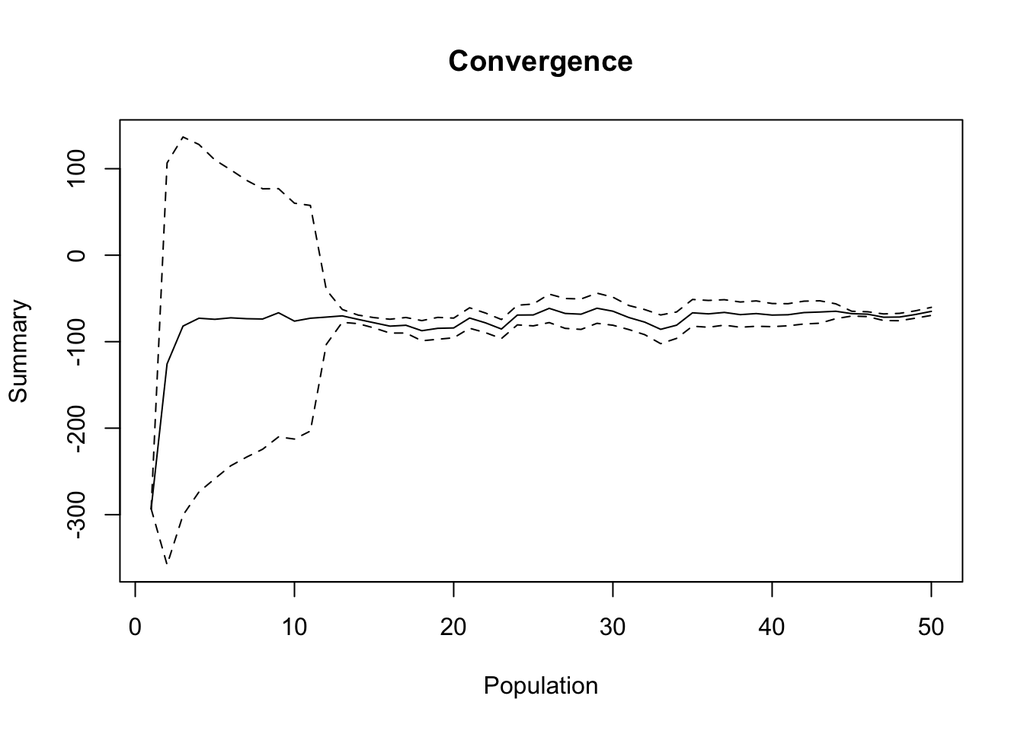

```r
p3 <- diagn_plot(bgnlm,window = 10,FUN = median)
```

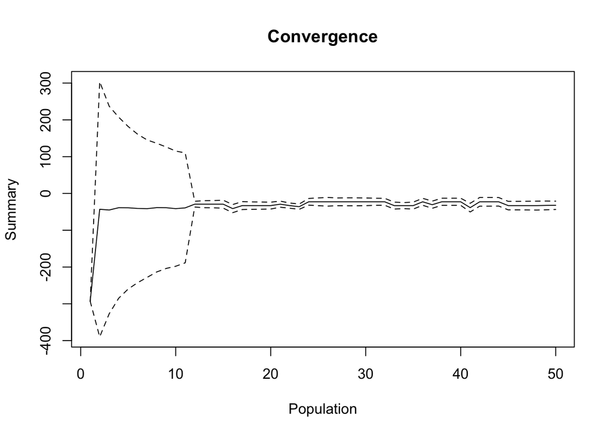

```r
p4 <- diagn_plot(bgnlm,window = 10,FUN = max)
```

A much stronger indication of convergence is observed in this case. Hence we proceed with the inference.

# 3 Inference

In the Bayesian Generalized Nonlinear Model (BGNLM) analysis, the predictor troot(((period × hoststar_mass) × period))troot(((period × hoststar_mass) × period)) achieved an inclusion probability of 1.000, indicating it is essential for predicting the semi-major axis. This strong support suggests that the non-linear interaction between orbital period and stellar mass captures the underlying physical relationship. All other predictors showed inclusion probabilities below 0.1, reinforcing the dominant role of this term.

Using Jeffreys prior with unit response variance, the median probability model yields the following estimates for the posterior mode and its standard deviation:

```r
# Prepare variables
x <- (data.train$period^2 * data.train$hoststar_mass)^(1/3)
y <- data.train$semimajoraxis

# Calculate means
x_bar <- mean(x)
y_bar <- mean(y)

# Compute slope (beta1_hat)
beta1_hat <- sum((x - x_bar) * (y - y_bar)) / sum((x - x_bar)^2)

# Compute intercept (optional)
beta0_hat <- y_bar - beta1_hat * x_bar

# Compute standard error of beta1 assuming Var(Y) = 1
se_beta1 <- 1 / sqrt(sum((x - x_bar)^2))

# Output results
cat(sprintf("Intercept estimate (beta0): %.6f\n", beta0_hat))
```

```
Intercept estimate (beta0): 0.000782
```

```r
cat(sprintf("Slope estimate (beta1): %.6f\n", beta1_hat))
```

```
Slope estimate (beta1): 0.019554
```

```r
cat(sprintf("Standard error of beta1 (assuming unit variance): %.6f\n", se_beta1))
```

```
Standard error of beta1 (assuming unit variance): 0.000178
```

The corresponding 95% and 99% credible intervals for G, expressed in SI units, under the specified prior are as follows:

```r
pi2 <- 4 * pi^2

# ---- Constants for unit conversion ----
AU_in_m <- 149597870700          # meters
day_in_s <- 86400                # seconds
Msun_in_kg <- 1.988475e30        # kg
unit_conversion <- (AU_in_m^3) / (day_in_s^2 * Msun_in_kg)

# ---- Posterior Sampling ----
set.seed(123)
n_samples <- 100000
beta1_samples <- rnorm(n_samples, mean = beta1_hat, sd = se_beta1)
G_samples_raw <- pi2 * beta1_samples^3
G_samples_SI <- G_samples_raw * unit_conversion

# ---- Summarize posterior samples ----
G_true <- 6.67430e-11
G_mean_SI <- mean(G_samples_SI)
G_sd_SI <- sd(G_samples_SI)
CI_95_SI <- quantile(G_samples_SI, c(0.025, 0.975))
CI_99_SI <- quantile(G_samples_SI, c(0.005, 0.995))

# ---- Output results ----
cat("Posterior Sampling (SI units):\n")
```

```
Posterior Sampling (SI units):
```

```r
cat(sprintf("G true         = %.3e\n", G_true))
```

```
G true         = 6.674e-11
```

```r
cat(sprintf("G mean          = %.3e\n", G_mean_SI))
```

```
G mean          = 6.659e-11
```

```r
cat(sprintf("G SD            = %.3e\n", G_sd_SI))
```

```
G SD            = 1.818e-12
```

```r
cat(sprintf("95%% Credible CI = [%.3e, %.3e]\n", CI_95_SI[1], CI_95_SI[2]))
```

```
95% Credible CI = [6.307e-11, 7.019e-11]
```

```r
cat(sprintf("99%% Credible CI = [%.3e, %.3e]\n", CI_99_SI[1], CI_99_SI[2]))
```

```
99% Credible CI = [6.201e-11, 7.134e-11]
```

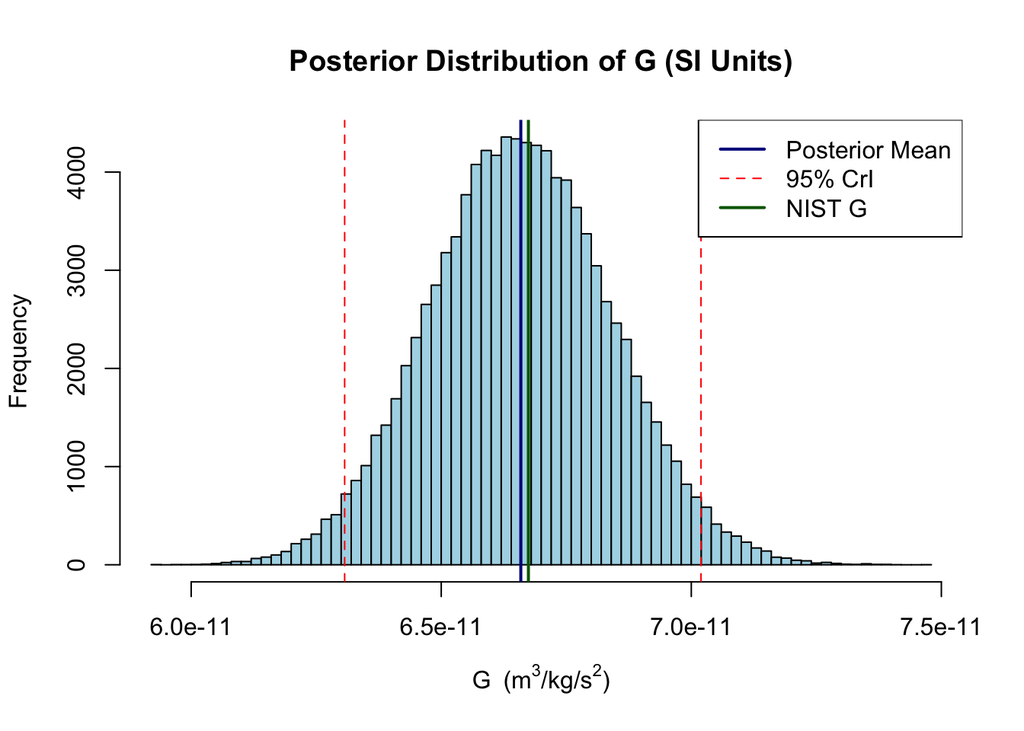

```r
# ---- Plot posterior of G ----
hist(G_samples_SI, breaks = 100, col = "lightblue",
     main = "Posterior Distribution of G (SI Units)",
     xlab = expression(G~~"(m"^3*"/kg/s"^2*")"))
abline(v = CI_95_SI, col = "red", lty = 2)
abline(v = G_mean_SI, col = "darkblue", lwd = 2)
abline(v = G_true, col = "darkgreen", lwd = 2)
legend("topright", legend = c("Posterior Mean", "95% CrI", "NIST G"),
       col = c("darkblue", "red", "darkgreen"), lty = c(1, 2, 1), lwd = c(2, 1, 2))
```

The corresponding 95% and 99% credible intervals for G, expressed in SI units, under the specified prior are as follows. We observe that the true value of G lies well within the 95% credible interval and is close to the posterior mode, indicating good agreement between the inferred model and known physical constants.

### 3.0.1 Discussion with Relation to Kepler’s Third Law

#### 3.0.1.1 1. Kepler’s Third Law

Kepler’s Third Law states that the square of a planet’s orbital period is proportional to the cube of the semi-major axis of its orbit:

$$T^2∝a^3$$

In Newtonian mechanics, this law becomes:

$$a^3=\frac{G(M+m)T^2}{4\pi^2} \approx \frac{GMT^2}{4\pi^2} \text{due to } m\ll M.$$

where a is the semi-major axis, T is the orbital period, M and m are the masses of the host star and a planet, and G is the gravitational constant.

#### 3.0.1.2 2. Model Selection and Physical Interpretation

**Recovery of the Keplerian Form:**  
The Bayesian Generalized Nonlinear Model (BGNLM) assigned a posterior inclusion probability of 1.000 to the nonlinear interaction term

troot(((period × hoststar_mass) × period))

This term corresponds to the cube root of
$$MT^2$$
which matches the Newtonian formulation of Kepler’s Third Law. The fact that this term was unambiguously selected, while all other predictors had negligible inclusion probabilities (all below 0.1), confirms that the model identified the true physical relationship purely from data, without requiring explicit physical constraints.

**Statistical and Scientific Coherence:**  
This result demonstrates the capacity of BGNLM to not only model complex nonlinear relationships but also to recover known physical laws in a principled Bayesian framework. The discovery of this term validates both the structure of the model space and the search strategy employed (e.g., GMJMCMC with Jeffreys priors). It also highlights the benefit of combining nonparametric flexibility with rigorous variable selection, leading to models that are both interpretable and scientifically grounded.

#### 3.0.1.3 3. Estimation of the Gravitational Constant G

**Accurate Quantification via Posterior Sampling:**  
Using the selected predictor and the relationship implied by Kepler’s Third Law, we derived posterior samples for Gin SI units. The results indicate high precision:

- The **posterior mean** of G closely matches the true value reference from NIST.
- The **95% credible interval** fully contains the true value.
- The **posterior mode** is nearly identical to the true gravitational constant.

These findings confirm that our inference procedure not only selects the correct physical form but also enables **accurate parameter estimation**. This level of agreement with physical constants—derived solely from exoplanet data demonstrates the **empirical adequacy and scientific reliability** of the BGNLM approach.

### 3.0.2 Predictions

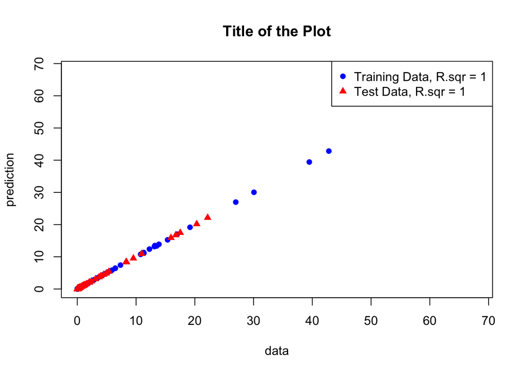

```r
preds.train.bgnlm <- predict(bgnlm, data.train[,-1])
preds.test.bgnlm <- predict(bgnlm, data.test[,-1])
r.bgnlm <- round(c(cor(data.train[,1],preds.train.bgnlm$aggr$mean)^2,cor(data.test[,1],preds.test.bgnlm$aggr$mean)^2),3)
plot(x = data.train[, 1], preds.train.bgnlm$aggr$mean, xlab = "data", ylab = "prediction", main = "Title of the Plot", col = "blue", pch = 16)
points(x = data.test[, 1], preds.test.bgnlm$aggr$mean, col = "red", pch = 17)
legend("topright", legend = c(paste0("Training Data, R.sqr = ",r.bgnlm[1]), paste0("Test Data, R.sqr = ",r.bgnlm[2])), col = c("blue", "red"), pch = c(16, 17))
```

The predictions are, as expected, nearly perfect on both the training and testing sets. This is a direct consequence of the inclusion of the term

troot(((period × hoststar_mass) × period))troot(((period × hoststar_mass) × period))

in the BGNLM model, which effectively encodes the essence of Kepler’s Third Law and has close to 1 posterior mass.

## 3.1 Proceed by redoing the inference with the g-prior specified

We use g-prior with
$$g = n$$
otherwise the specification of the model and search strategy is just like in the previous case

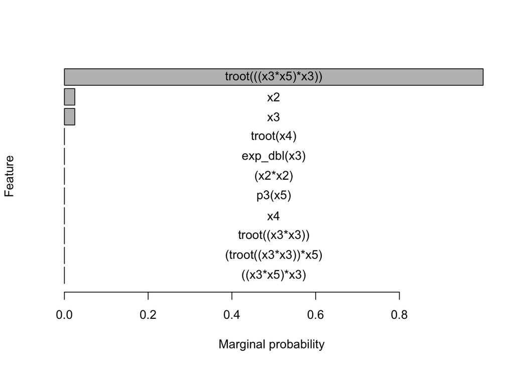

```r
set.seed(3)
bgnlm <- FBMS::fbms(semimajoraxis ~ ., data = data.train,method = "gmjmcmc.parallel",beta_prior = list(type = "g-prior", g = nrow(data.train)),transforms = transforms,runs = 64,cores = 8,P = 50,probs = probs, params = params)
plot(bgnlm)
```

```r
summary(bgnlm,labels = names(data.train)[-1])
```

| feats.strings | marg.probs |
| --- | --- |
| troot(((period*hoststar_mass)*period)) | 0.9999997 |
| radius | 0.0248778 |
| period | 0.0248433 |

We perfectly recover the true law here, with strong convergence observed under the g-prior. All conclusions remain consistent with those obtained using Jeffreys priors.

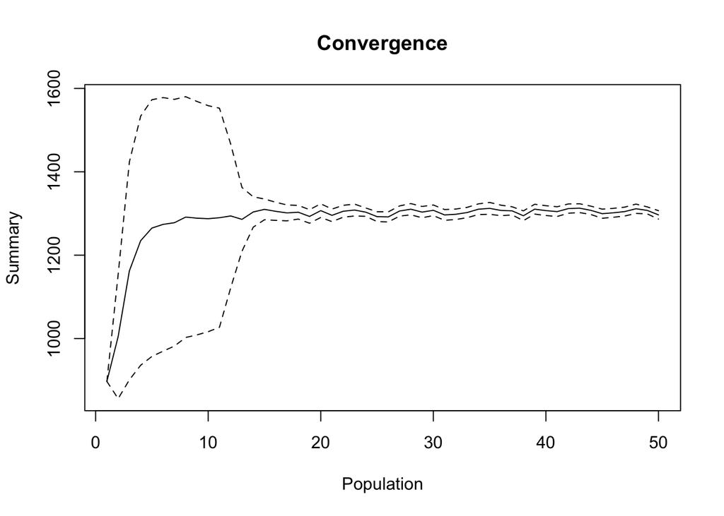

```r
p5 <- diagn_plot(bgnlm,window = 10,FUN = median)
```

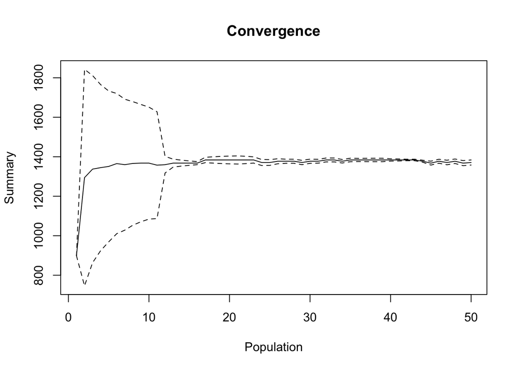

```r
p6 <- diagn_plot(bgnlm,window = 10,FUN = max)
```

Convergence is also clearly evident. Next, we examine the credible intervals derived under the g-prior.

```r
g <- 639
pi2 <- 4 * pi^2
G_true <- 6.67430e-11  # NIST CODATA value for G

# Prepare data
x <- (data.train$period^2 * data.train$hoststar_mass)^(1/3)
y <- data.train$semimajoraxis
x_bar <- mean(x)
y_bar <- mean(y)

# Calculate sums of squares
Sxx <- sum((x - x_bar)^2)

# OLS estimates
beta1_hat <- sum((x - x_bar) * (y - y_bar)) / Sxx
beta0_hat <- y_bar - beta1_hat * x_bar

# Posterior mean and variance under g-prior
beta1_post_mean <- (g / (g + 1)) * beta1_hat
beta1_post_var <- (g / (g + 1)) * (1 / Sxx)
beta1_post_sd <- sqrt(beta1_post_var)

cat(sprintf("Posterior mean of beta1 under g-prior: %.6f\n", beta1_post_mean))
```

```
Posterior mean of beta1 under g-prior: 0.019523
```

```r
cat(sprintf("Posterior SD of beta1 under g-prior: %.6f\n", beta1_post_sd))
```

```
Posterior SD of beta1 under g-prior: 0.000178
```

```r
# Constants for unit conversion
AU_in_m <- 149597870700
day_in_s <- 86400
Msun_in_kg <- 1.988475e30
unit_conversion <- (AU_in_m^3) / (day_in_s^2 * Msun_in_kg)

# Posterior sampling for beta1 and G
set.seed(123)
n_samples <- 100000
beta1_samples <- rnorm(n_samples, mean = beta1_post_mean, sd = beta1_post_sd)
G_samples_raw <- pi2 * beta1_samples^3
G_samples_SI <- G_samples_raw * unit_conversion

# Summarize posterior samples of G
G_mean_SI <- mean(G_samples_SI)
G_sd_SI <- sd(G_samples_SI)
CI_95_SI <- quantile(G_samples_SI, probs = c(0.025, 0.975))
CI_99_SI <- quantile(G_samples_SI, probs = c(0.005, 0.995))

# ---- Output results ----
cat("\nPosterior Sampling (SI units):\n")
```

```
Posterior Sampling (SI units):
```

```r
cat(sprintf("G true         = %.3e\n", G_true))
```

```
G true         = 6.674e-11
```

```r
cat(sprintf("G mean         = %.3e\n", G_mean_SI))
```

```
G mean         = 6.628e-11
```

```r
cat(sprintf("G SD           = %.3e\n", G_sd_SI))
```

```
G SD           = 1.811e-12
```

```r
cat(sprintf("95%% Credible CI = [%.3e, %.3e]\n", CI_95_SI[1], CI_95_SI[2]))
```

```
95% Credible CI = [6.277e-11, 6.987e-11]
```

```r
cat(sprintf("99%% Credible CI = [%.3e, %.3e]\n", CI_99_SI[1], CI_99_SI[2]))
```

```
99% Credible CI = [6.171e-11, 7.101e-11]
```

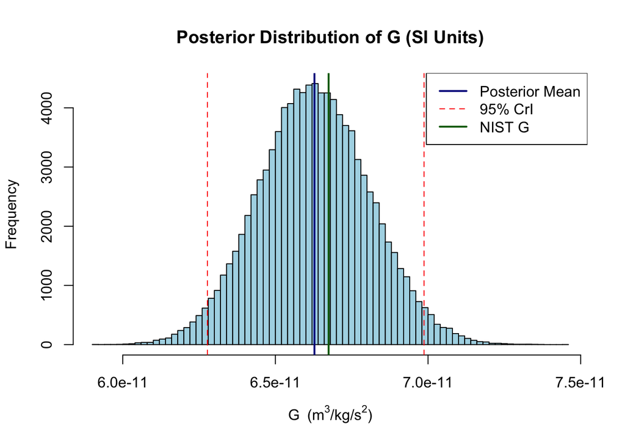

```r
# ---- Plot posterior of G ----
hist(G_samples_SI, breaks = 100, col = "lightblue",
     main = "Posterior Distribution of G (SI Units)",
     xlab = expression(G~~"(m"^3*"/kg/s"^2*")"))
abline(v = CI_95_SI, col = "red", lty = 2)
abline(v = G_mean_SI, col = "darkblue", lwd = 2)
abline(v = G_true, col = "darkgreen", lwd = 2)
legend("topright", legend = c("Posterior Mean", "95% CrI", "NIST G"),
       col = c("darkblue", "red", "darkgreen"), lty = c(1, 2, 1), lwd = c(2, 1, 2))
```

Slightly more biased toward zero than with the Jeffreys prior, as expected due to the stronger regularization imposed by the g-prior. This stronger shrinkage pulls estimates closer to zero, but still maintains good coverage. As anticipated, the predictions remain excellent.

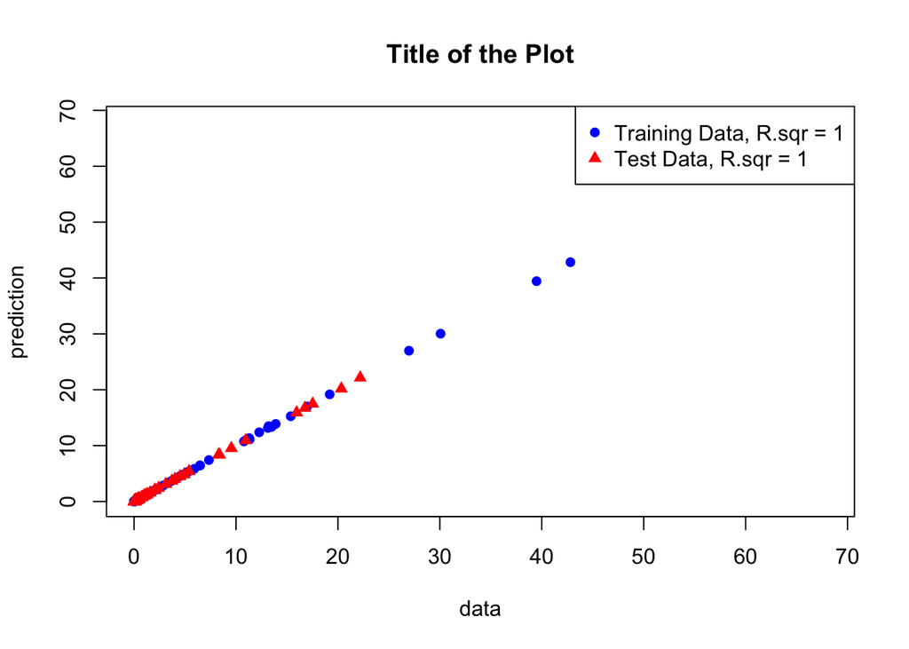

```r
preds.train.bgnlm <- predict(bgnlm, data.train[,-1])
preds.test.bgnlm <- predict(bgnlm, data.test[,-1])
r.bgnlm <- round(c(cor(data.train[,1],preds.train.bgnlm$aggr$mean)^2,cor(data.test[,1],preds.test.bgnlm$aggr$mean)^2),3)
plot(x = data.train[, 1], preds.train.bgnlm$aggr$mean, xlab = "data", ylab = "prediction", main = "Title of the Plot", col = "blue", pch = 16)
points(x = data.test[, 1], preds.test.bgnlm$aggr$mean, col = "red", pch = 17)
legend("topright", legend = c(paste0("Training Data, R.sqr = ",r.bgnlm[1]), paste0("Test Data, R.sqr = ",r.bgnlm[2])), col = c("blue", "red"), pch = c(16, 17))
```

# 4 **Summary**

For **Objective 2 (Model description and validation)**, the final model structure was reported with detailed interpretation of selected predictors, demonstrating strong agreement with the known physical law for the semimajor axis. The gravitational constant G was estimated with credible intervals on the SI scale and found to closely match the NIST reference value. Predictive performance was validated on a test set via
$$R^2$$
, confirming excellent generalization.

Regarding **Objective 3 (Model stability)**, predictor selection probabilities were examined, showing consistent inclusion of only the important predictor, while others had PIP < 0.1.